# Palmer Penguins and Tidymodels

MC

March 12, 2021

# 1 Shortcuts

- **Insert Chunk** : Ctrl + Alt + i
- **Excecute current line** : Ctrl + Enter / Alt + Enter
- **Excecute current chunck** : Ctrl + Shift + Enter
- **Insert pipeline operator ( %>% )** : Ctrl + Shift + m
- **Insert assignment operator (<-)** : Alt + -
- **Zoom editor :** Ctrl + Shift + 1
- **Show command palette** : Ctrl + Shift + p

# 2 Packages Install

```r
# install.packages("tidyverse")
# install.packages("tidymodels")
# install.packages("doParallel")
# install.packages("palmerpenguins")
# install.packages("hrbrthemes")
# install.packages("xgboost")
# install.packages("ranger")
# install.packages("glmnet")
# install.packages("kknn")
# install.packages("tictoc")
```

# 3 Packages Loading

```r
library(tidyverse)
library(tidymodels)
library(doParallel)
library(palmerpenguins)
library(hrbrthemes)
library(xgboost)
library(ranger)
library(glmnet)
library(kknn)
library(tictoc)
theme_set(hrbrthemes::theme_ipsum_rc())

# doParallel
cores <- parallel::detectCores(logical = FALSE)
registerDoParallel(cores = cores)

set.seed(77)
```

[Tidyverse Package](https://www.tidyverse.org/)

[Learn R for Data Science](https://r4ds.had.co.nz/index.html)

[Tidymodels](https://www.tidymodels.org/)

[Learn Tidymodels](https://www.tmwr.org/)

# 4 Data Wrangling

## 4.1 Data Loading

```r
penguins_data <-
  palmerpenguins::penguins

penguins_data %>% head()
```

| species | island | bill_length_mm | bill_depth_mm | flipper_length_mm | body_mass_g | sex | year |
| --- | --- | --- | --- | --- | --- | --- | --- |
| Adelie | Torgersen | 39.1 | 18.7 | 181 | 3750 | male | 2007 |
| Adelie | Torgersen | 39.5 | 17.4 | 186 | 3800 | female | 2007 |
| Adelie | Torgersen | 40.3 | 18.0 | 195 | 3250 | female | 2007 |
| Adelie | Torgersen | NA | NA | NA | NA | NA | 2007 |
| Adelie | Torgersen | 36.7 | 19.3 | 193 | 3450 | female | 2007 |
| Adelie | Torgersen | 39.3 | 20.6 | 190 | 3650 | male | 2007 |

```r
penguins_data %>% summary()
```

```
##       species          island    bill_length_mm  bill_depth_mm
##  Adelie   :152   Biscoe   :168   Min.   :32.10   Min.   :13.10
##  Chinstrap: 68   Dream    :124   1st Qu.:39.23   1st Qu.:15.60
##  Gentoo   :124   Torgersen: 52   Median :44.45   Median :17.30
##                                  Mean   :43.92   Mean   :17.15
##                                  3rd Qu.:48.50   3rd Qu.:18.70
##                                  Max.   :59.60   Max.   :21.50
##                                  NA's   :2       NA's   :2
##  flipper_length_mm  body_mass_g       sex           year
##  Min.   :172.0     Min.   :2700   female:165   Min.   :2007
##  1st Qu.:190.0     1st Qu.:3550   male  :168   1st Qu.:2007
##  Median :197.0     Median :4050   NA's  : 11   Median :2008
##  Mean   :200.9     Mean   :4202                Mean   :2008
##  3rd Qu.:213.0     3rd Qu.:4750                3rd Qu.:2009
##  Max.   :231.0     Max.   :6300                Max.   :2009
##  NA's   :2         NA's   :2
```

## 4.2 Data Preprocessing

Let’s filter NA’s and remove **year** and **island** column

```r
penguins_df <-
  penguins_data %>%
  filter(!is.na(sex)) %>%
  select(-year, -island)

head(penguins_df)
```

| species | bill_length_mm | bill_depth_mm | flipper_length_mm | body_mass_g | sex |
| --- | --- | --- | --- | --- | --- |
| Adelie | 39.1 | 18.7 | 181 | 3750 | male |
| Adelie | 39.5 | 17.4 | 186 | 3800 | female |
| Adelie | 40.3 | 18.0 | 195 | 3250 | female |
| Adelie | 36.7 | 19.3 | 193 | 3450 | female |
| Adelie | 39.3 | 20.6 | 190 | 3650 | male |
| Adelie | 38.9 | 17.8 | 181 | 3625 | female |

## 4.3 Initial Train/Test Split

First we’ll separate train / test with an initial stratified split:

[Rsample package](https://rsample.tidymodels.org/index.html)

```r
penguins_split <-
  rsample::initial_split(
    penguins_df,
    prop = 0.7,
    strata = species
  )

penguins_split
```

```
## <Analysis/Assess/Total>
## <235/98/333>
```

```r
training(penguins_split)
```

| species | bill_length_mm | bill_depth_mm | flipper_length_mm | body_mass_g | sex |
| --- | --- | --- | --- | --- | --- |
| Adelie | 39.1 | 18.7 | 181 | 3750 | male |
| Adelie | 39.5 | 17.4 | 186 | 3800 | female |
| Adelie | 39.3 | 20.6 | 190 | 3650 | male |
| Adelie | 39.2 | 19.6 | 195 | 4675 | male |
| Adelie | 34.6 | 21.1 | 198 | 4400 | male |
| Adelie | 36.6 | 17.8 | 185 | 3700 | female |
| Adelie | 38.7 | 19.0 | 195 | 3450 | female |
| Adelie | 42.5 | 20.7 | 197 | 4500 | male |
| Adelie | 34.4 | 18.4 | 184 | 3325 | female |
| Adelie | 46.0 | 21.5 | 194 | 4200 | male |

[output cut: 225 more lines]

```r
testing(penguins_split)
```

| species | bill_length_mm | bill_depth_mm | flipper_length_mm | body_mass_g | sex |
| --- | --- | --- | --- | --- | --- |
| Adelie | 40.3 | 18.0 | 195 | 3250 | female |
| Adelie | 36.7 | 19.3 | 193 | 3450 | female |
| Adelie | 38.9 | 17.8 | 181 | 3625 | female |
| Adelie | 41.1 | 17.6 | 182 | 3200 | female |
| Adelie | 38.6 | 21.2 | 191 | 3800 | male |
| Adelie | 37.8 | 18.3 | 174 | 3400 | female |
| Adelie | 35.9 | 19.2 | 189 | 3800 | female |
| Adelie | 38.2 | 18.1 | 185 | 3950 | male |
| Adelie | 40.9 | 18.9 | 184 | 3900 | male |
| Adelie | 39.8 | 19.1 | 184 | 4650 | male |

[output cut: 88 more lines]

# 5 Baseline Experiment

[Parsnip package](https://www.tidymodels.org/find/parsnip/)

[Parsnip models list](https://www.tidymodels.org/find/parsnip/)

[Yardstick package](https://yardstick.tidymodels.org/)

Let’s predict the **specie** of the penguin

```r
knn_fit <-
  nearest_neighbor() %>%
  set_engine("kknn") %>%
  set_mode("classification") %>%
  fit(species ~ ., data = training(penguins_split))
```

## 5.1 Baseline Metrics

```r
preds <-
  predict(knn_fit, new_data = testing(penguins_split))

actual <-
  testing(penguins_split) %>% select(species)

yardstick::f_meas_vec(truth = actual$species, estimate = preds$.pred_class)
```

```
## [1] 0.9876216
```

# 6 Tidymodels Definitions

## 6.1 Models

[Parsnip models list](https://www.tidymodels.org/find/parsnip/)

[Tune package](https://tune.tidymodels.org/)

```r
ranger_model <-
  parsnip::rand_forest(mtry = tune(), min_n = tune()) %>%
  set_engine("ranger") %>%
  set_mode("classification")

glm_model <-
  parsnip::multinom_reg(penalty = tune(), mixture = tune()) %>%
  set_engine("glmnet") %>%
  set_mode("classification")

xgboost_model <-
  parsnip::boost_tree(mtry = tune(), learn_rate = tune()) %>%
  set_engine("xgboost") %>%
  set_mode("classification")

pull_dials_object(glm_model, "mixture")
```

```
## Proportion of lasso Penalty (quantitative)
## Range: [0, 1]
```

```r
pull_dials_object(ranger_model, "mtry")
```

```
## # Randomly Selected Predictors (quantitative)
## Range: [1, ?]
```

## 6.2 Grids

[Dials package](https://dials.tidymodels.org/)

There’s no need to know the tuning parameters ranges!!!

```r
ranger_grid <-
  parameters(ranger_model) %>%
  finalize(select(training(penguins_split), -species)) %>% # beacuse of mtry
  dials::grid_regular(levels = 4)

ranger_grid
```

| mtry | min_n |
| --- | --- |
| 1 | 2 |
| 2 | 2 |
| 3 | 2 |
| 5 | 2 |
| 1 | 14 |
| 2 | 14 |
| 3 | 14 |
| 5 | 14 |
| 1 | 27 |
| 2 | 27 |

[output cut: 6 more lines]

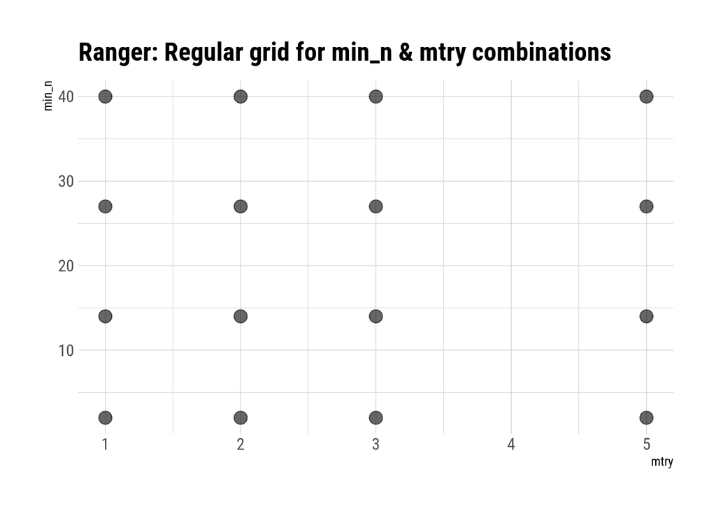

```r
ranger_grid %>% ggplot(aes(mtry, min_n)) +
  geom_point(size = 4, alpha = 0.6) +
  labs(title = "Ranger: Regular grid for min_n & mtry combinations")
```

```r
glm_grid <-
  parameters(glm_model) %>%
  grid_random(size = 20)

glm_grid
```

| penalty | mixture |
| --- | --- |
| 4.335232e-04 | 0.99057077 |
| 4.468042e-06 | 0.36063392 |
| 2.281723e-07 | 0.41565784 |
| 4.949974e-01 | 0.49198816 |
| 1.561217e-07 | 0.52019240 |
| 2.723615e-04 | 0.67451239 |
| 4.824015e-05 | 0.01235218 |
| 9.068351e-01 | 0.92845391 |
| 4.745152e-01 | 0.82113175 |
| 2.726528e-07 | 0.97868200 |

[output cut: 10 more lines]

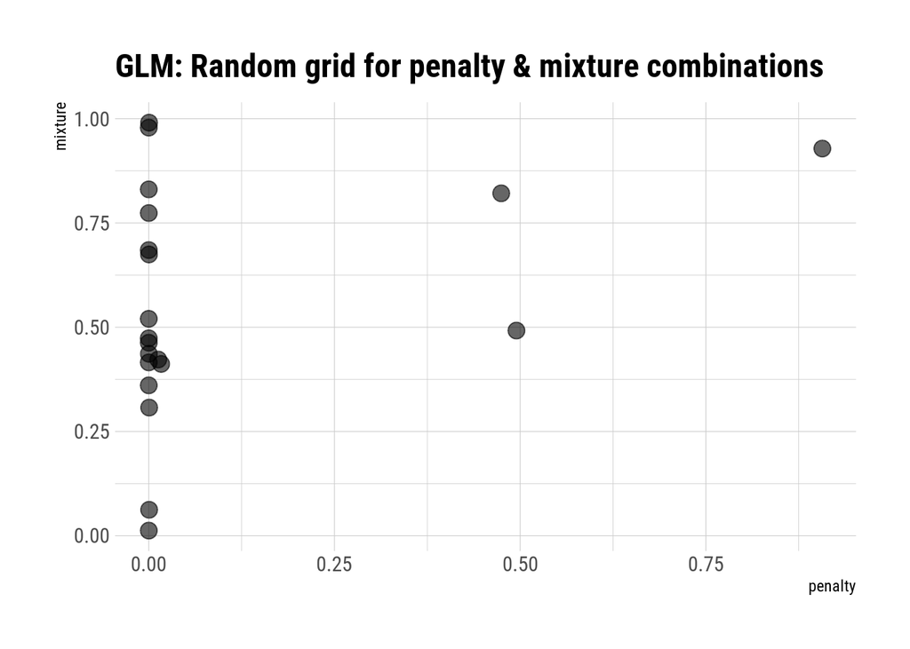

```r
glm_grid %>% ggplot(aes(penalty, mixture)) +
  geom_point(size = 4, alpha = 0.6) +
  labs(title = "GLM: Random grid for penalty & mixture combinations")
```

```r
xgboost_grid <-
  parameters(xgboost_model) %>%
  finalize(select(training(penguins_split), -species)) %>%
  grid_max_entropy(size = 20)
xgboost_grid
```

| mtry | learn_rate |
| --- | --- |
| 5 | 1.219203e-10 |
| 3 | 1.402019e-10 |
| 4 | 4.885052e-06 |
| 3 | 2.850766e-04 |
| 1 | 1.140733e-09 |
| 3 | 7.611991e-02 |
| 1 | 5.716323e-08 |
| 3 | 5.140629e-08 |
| 4 | 4.288844e-05 |
| 2 | 1.723915e-10 |

[output cut: 10 more lines]

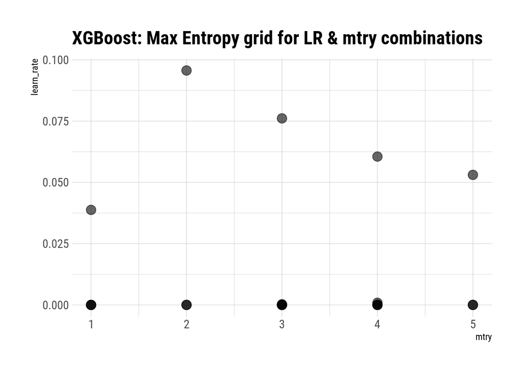

```r
xgboost_grid %>% ggplot(aes(mtry, learn_rate)) +
  geom_point(size = 4, alpha = 0.6) +
  labs(title = "XGBoost: Max Entropy grid for LR & mtry combinations")
```

## 6.3 Recipes

[Recipes Package](https://recipes.tidymodels.org/)

[Ordering Recipes Steps](https://recipes.tidymodels.org/articles/Ordering.html)

```r
recipe_base <-
  recipe(species ~ ., data = training(penguins_split)) %>%
  step_dummy(all_nominal(), -all_outcomes(), one_hot = TRUE) # Create dummy variables (which glmnet needs)

# Apply exponential transformation
recipe_1 <-
  recipe_base %>%
  step_YeoJohnson(all_numeric())

recipe_1 %>%
  prep() %>%
  juice() %>%
  summary()
```

```
##  bill_length_mm   bill_depth_mm   flipper_length_mm  body_mass_g
##  Min.   : 53.94   Min.   :31.23   Min.   :0.6053    Min.   :2.284
##  1st Qu.: 68.88   1st Qu.:39.57   1st Qu.:0.6053    1st Qu.:2.292
##  Median : 80.33   Median :46.62   Median :0.6053    Median :2.296
##  Mean   : 78.53   Mean   :45.92   Mean   :0.6053    Mean   :2.296
##  3rd Qu.: 88.09   3rd Qu.:51.51   3rd Qu.:0.6053    3rd Qu.:2.301
##  Max.   :103.60   Max.   :62.13   Max.   :0.6053    Max.   :2.308
##       species      sex_female        sex_male
##  Adelie   :103   Min.   :0.0000   Min.   :0.0000
##  Chinstrap: 48   1st Qu.:0.0000   1st Qu.:0.0000
##  Gentoo   : 84   Median :0.0000   Median :1.0000
##                  Mean   :0.4596   Mean   :0.5404
##                  3rd Qu.:1.0000   3rd Qu.:1.0000
##                  Max.   :1.0000   Max.   :1.0000
```

```r
# Apply normalization
recipe_2 <-
  recipe_base %>%
  step_normalize(all_numeric())

recipe_2 %>%
  prep() %>%
  juice() %>%
  summary()
```

```
##  bill_length_mm    bill_depth_mm     flipper_length_mm  body_mass_g
##  Min.   :-2.2517   Min.   :-2.0608   Min.   :-2.1141   Min.   :-1.7787
##  1st Qu.:-0.8611   1st Qu.:-0.8476   1st Qu.:-0.8156   1st Qu.:-0.8244
##  Median : 0.1725   Median : 0.1180   Median :-0.3107   Median :-0.1882
##  Mean   : 0.0000   Mean   : 0.0000   Mean   : 0.0000   Mean   : 0.0000
##  3rd Qu.: 0.8584   3rd Qu.: 0.7617   3rd Qu.: 0.8436   3rd Qu.: 0.7662
##  Max.   : 2.2020   Max.   : 2.0987   Max.   : 2.0699   Max.   : 2.6112
##       species      sex_female         sex_male
##  Adelie   :103   Min.   :-0.9202   Min.   :-1.0821
##  Chinstrap: 48   1st Qu.:-0.9202   1st Qu.:-1.0821
##  Gentoo   : 84   Median :-0.9202   Median : 0.9202
##                  Mean   : 0.0000   Mean   : 0.0000
##                  3rd Qu.: 1.0821   3rd Qu.: 0.9202
##                  Max.   : 1.0821   Max.   : 0.9202
```

## 6.4 Metrics

[Yardstick Package](https://yardstick.tidymodels.org/index.html)

```r
model_metrics <-
  yardstick::metric_set(f_meas, pr_auc)
```

## 6.5 K-Fold CV

```r
data_penguins_5_cv_folds <-
  rsample::vfold_cv(
    v = 5,
    data = training(penguins_split),
    strata = species
  )
data_penguins_5_cv_folds
```

| splits | id |
| --- | --- |
|  | Fold1 |
|  | Fold2 |
|  | Fold3 |
|  | Fold4 |
|  | Fold5 |

```r
data_penguins_5_cv_folds$splits[[1]]$data
```

| species | bill_length_mm | bill_depth_mm | flipper_length_mm | body_mass_g | sex |
| --- | --- | --- | --- | --- | --- |
| Adelie | 39.1 | 18.7 | 181 | 3750 | male |
| Adelie | 39.5 | 17.4 | 186 | 3800 | female |
| Adelie | 39.3 | 20.6 | 190 | 3650 | male |
| Adelie | 39.2 | 19.6 | 195 | 4675 | male |
| Adelie | 34.6 | 21.1 | 198 | 4400 | male |
| Adelie | 36.6 | 17.8 | 185 | 3700 | female |
| Adelie | 38.7 | 19.0 | 195 | 3450 | female |
| Adelie | 42.5 | 20.7 | 197 | 4500 | male |
| Adelie | 34.4 | 18.4 | 184 | 3325 | female |
| Adelie | 46.0 | 21.5 | 194 | 4200 | male |

[output cut: 225 more lines]

# 7 Model Training

## 7.1 Option 1: Tune Grids

### 7.1.1 Workflows Creation

[Workflow Package](https://workflows.tidymodels.org/)

```r
ranger_r1_workflow <-
  workflows::workflow() %>%
  add_model(ranger_model) %>%
  add_recipe(recipe_1)

glm_r2_workflow <-
  workflows::workflow() %>%
  add_model(glm_model) %>%
  add_recipe(recipe_2)

xgboost_r2_workflow <-
  workflows::workflow() %>%
  add_model(xgboost_model) %>%
  add_recipe(recipe_2)
```

### 7.1.2 Training: Gridsearch

[Tune Package](https://tune.tidymodels.org/)

- Random Forest (ranger) will train 16 models ( 1 per HP combination) * 5 folds
- Multinomial Regression (GLM) will train 20 models * 5 folds

```r
tic("Ranger tune grid training duration ")
ranger_tuned <-
  tune::tune_grid(
    object = ranger_r1_workflow,
    resamples = data_penguins_5_cv_folds,
    grid = ranger_grid,
    metrics = model_metrics,
    control = tune::control_grid(save_pred = TRUE)
  )
toc(log = TRUE)
```

```
## Ranger tune grid training duration : 10.382 sec elapsed
```

```r
tic("GLM tune grid training duration ")
glm_tuned <-
  tune::tune_grid(
    object = glm_r2_workflow,
    resamples = data_penguins_5_cv_folds,
    grid = glm_grid,
    metrics = model_metrics,
    control = tune::control_grid(save_pred = TRUE)
  )
toc(log = TRUE)
```

```
## GLM tune grid training duration : 14.206 sec elapsed
```

```r
tic("XGBoost tune grid training duration ")
xgboost_tuned <-
  tune::tune_grid(
    object = xgboost_r2_workflow,
    resamples = data_penguins_5_cv_folds,
    grid = xgboost_grid,
    metrics = model_metrics,
    control = tune::control_grid(save_pred = TRUE)
  )
toc(log = TRUE)
```

```
## XGBoost tune grid training duration : 14.275 sec elapsed
```

#### 7.1.2.1 Optional: Use Racing methods

[Finetune Blog](https://www.tidyverse.org/blog/2020/12/finetune-0-0-1/)

```r
#install.packages("finetune")
library(finetune)
tic("Tune race training duration ")
ft_xgboost_tuned <-
  finetune::tune_race_anova(
    object = xgboost_r2_workflow,
    resamples = data_penguins_5_cv_folds,
    grid = xgboost_grid,
    metrics = model_metrics,
    control = control_race(verbose_elim = TRUE) # 66
  )
```

```
## ℹ Racing will maximize the f_meas metric.
```

```
## ℹ Resamples are analyzed in a random order.
```

[output not shown]

```
## ℹ Fold4:  2 eliminated; 13 candidates remain.
```

```r
toc(log = TRUE)
```

```
## Tune race training duration : 19.837 sec elapsed
```

##### 7.1.2.1.1 Plot Racing Methods

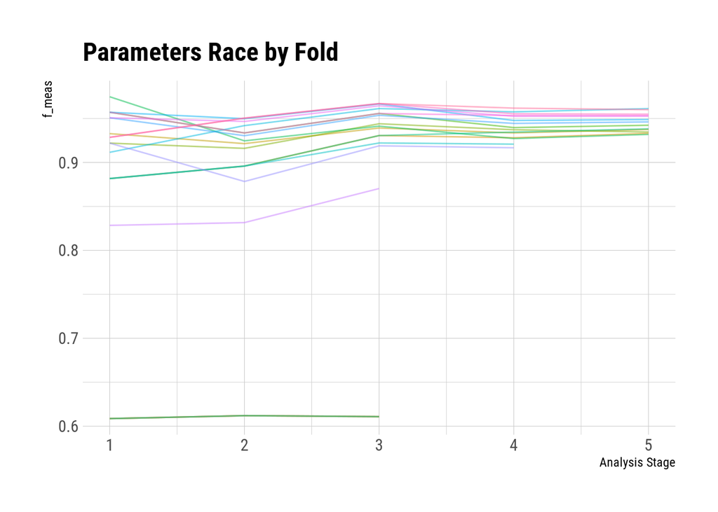

```r
plot_race(ft_xgboost_tuned) + labs(title = "Parameters Race by Fold")
```

Each line corresponds to a tuning parameter combination. Models with suboptimal f_meas scores are eliminated .

### 7.1.3 Results

```r
bind_cols(
  tibble(model = c("Ranger", "GLM", "XGBoost")),
  bind_rows(
    ranger_tuned %>%
      collect_metrics() %>% group_by(.metric) %>% summarise(best_va = max(mean, na.rm = TRUE)) %>% arrange(.metric) %>% pivot_wider(names_from = .metric, values_from = best_va),
    glm_tuned %>%
      collect_metrics() %>% group_by(.metric) %>% summarise(best_va = max(mean, na.rm = TRUE)) %>% arrange(.metric) %>% pivot_wider(names_from = .metric, values_from = best_va),
    xgboost_tuned %>%
      collect_metrics() %>% group_by(.metric) %>% summarise(best_va = max(mean, na.rm = TRUE)) %>% arrange(.metric) %>% pivot_wider(names_from = .metric, values_from = best_va)
  )
)
```

| model | f_meas | pr_auc |
| --- | --- | --- |
| Ranger | 0.9838457 | 0.9916473 |
| GLM | 0.9944524 | 0.9990554 |
| XGBoost | 0.9644765 | 0.9851309 |

We’ll select GLM and get the the best HP group

```r
# Metrics for each model
glm_tuned %>% collect_metrics() # 20 models and 2 metrics
```

| penalty | mixture | .metric | .estimator | mean | n | std_err | .config |
| --- | --- | --- | --- | --- | --- | --- | --- |
| 4.824015e-05 | 0.01235218 | f_meas | macro | 0.9893933 | 5 | 0.0065067453 | Preprocessor1_Model01 |
| 4.824015e-05 | 0.01235218 | pr_auc | macro | 0.9990554 | 5 | 0.0009445914 | Preprocessor1_Model01 |
| 4.901345e-04 | 0.06223151 | f_meas | macro | 0.9944524 | 5 | 0.0055475849 | Preprocessor1_Model02 |
| 4.901345e-04 | 0.06223151 | pr_auc | macro | 0.9990554 | 5 | 0.0009445914 | Preprocessor1_Model02 |
| 5.358195e-04 | 0.30729696 | f_meas | macro | 0.9944524 | 5 | 0.0055475849 | Preprocessor1_Model03 |
| 5.358195e-04 | 0.30729696 | pr_auc | macro | 0.9990554 | 5 | 0.0009445914 | Preprocessor1_Model03 |
| 4.468042e-06 | 0.36063392 | f_meas | macro | 0.9944524 | 5 | 0.0055475849 | Preprocessor1_Model04 |
| 4.468042e-06 | 0.36063392 | pr_auc | macro | 0.9990554 | 5 | 0.0009445914 | Preprocessor1_Model04 |
| 1.668951e-02 | 0.41198823 | f_meas | macro | 0.9893933 | 5 | 0.0065067453 | Preprocessor1_Model05 |
| 1.668951e-02 | 0.41198823 | pr_auc | macro | 0.9989077 | 5 | 0.0009188601 | Preprocessor1_Model05 |

[output cut: 30 more lines]

```r
# Best metric value
glm_tuned %>%
  collect_metrics() %>%
  group_by(.metric) %>%
  summarise(best_va = max(mean, na.rm = TRUE)) %>%
  arrange(.metric)
```

| .metric | best_va |
| --- | --- |
| f_meas | 0.9944524 |
| pr_auc | 0.9990554 |

```r
# Best HPO combination
glm_tuned %>% select_best(metric = "f_meas")
```

| penalty | mixture | .config |
| --- | --- | --- |
| 0.0004901345 | 0.06223151 | Preprocessor1_Model02 |

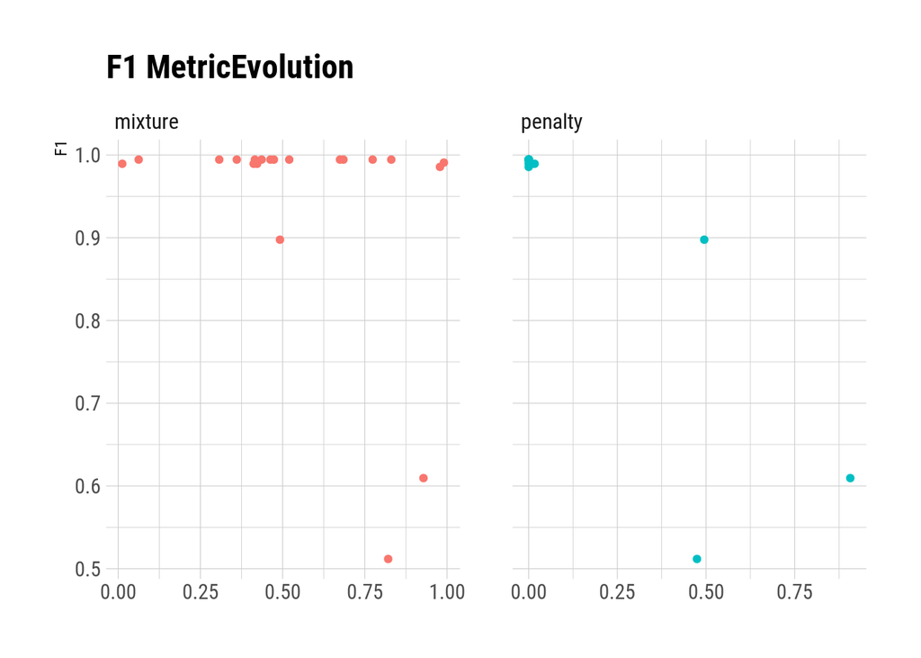

```r
glm_tuned %>%
  collect_metrics() %>%
  filter(.metric == "f_meas") %>%
  select(mean, penalty, mixture) %>%
  pivot_longer(penalty:mixture,
    values_to = "value",
    names_to = "parameter"
  ) %>%
  ggplot(aes(value, mean, color = parameter)) +
  geom_point(show.legend = FALSE) +
  facet_wrap(~parameter, scales = "free_x") +
  labs(x = NULL, y = "F1", title = "F1 MetricEvolution")
```

Based on this plot we could explore a more limited space of HP

### 7.1.4 Finalize Tune Model

Let’s take best parameters and create the final model

```r
best_f1 <-
  select_best(glm_tuned, metric = "f_meas")

final_model_op1 <-
  finalize_workflow(
    x = glm_r2_workflow,
    parameters = best_f1
  )

final_model_op1
```

```
## ══ Workflow ════════════════════════════════════════════════════════════════════
## Preprocessor: Recipe
## Model: multinom_reg()
##
## ── Preprocessor ────────────────────────────────────────────────────────────────
## 2 Recipe Steps
##
## ● step_dummy()
## ● step_normalize()
##
## ── Model ───────────────────────────────────────────────────────────────────────
## Multinomial Regression Model Specification (classification)
##
## Main Arguments:
##   penalty = 0.000490134537369813
##   mixture = 0.0622315076179802
##
## Computational engine: glmnet
```

### 7.1.5 Last Fit Tune Model

Let’s fit to the whole training data and then evaluates on test

```r
tic("Train final model Tune")
penguins_last_fit <-
  last_fit(final_model_op1,
    penguins_split,
    metrics = model_metrics
  )
toc(log = TRUE)
```

```
## Train final model Tune: 0.561 sec elapsed
```

#### 7.1.5.1 Last Fit Tune Model Metrics

```r
collect_metrics(penguins_last_fit) %>%
  arrange(.metric)
```

| .metric | .estimator | .estimate | .config |
| --- | --- | --- | --- |
| f_meas | macro | 0.9876216 | Preprocessor1_Model1 |
| pr_auc | macro | 1.0000000 | Preprocessor1_Model1 |

```r
penguins_last_fit %>%
  collect_predictions() %>%
  conf_mat(truth = species, estimate = .pred_class)
```

```
##            Truth
## Prediction  Adelie Chinstrap Gentoo
##   Adelie        43         1      0
##   Chinstrap      0        19      0
##   Gentoo         0         0     35
```

```r
penguins_last_fit %>%
  pull(.predictions) %>%
  as.data.frame() %>%
  filter(.pred_class != species)
```

| .pred_class | .row | .pred_Adelie | .pred_Chinstrap | .pred_Gentoo | species | .config |
| --- | --- | --- | --- | --- | --- | --- |
| Adelie | 286 | 0.5913412 | 0.4069361 | 0.00172266 | Chinstrap | Preprocessor1_Model1 |

### 7.1.6 Feature Importance

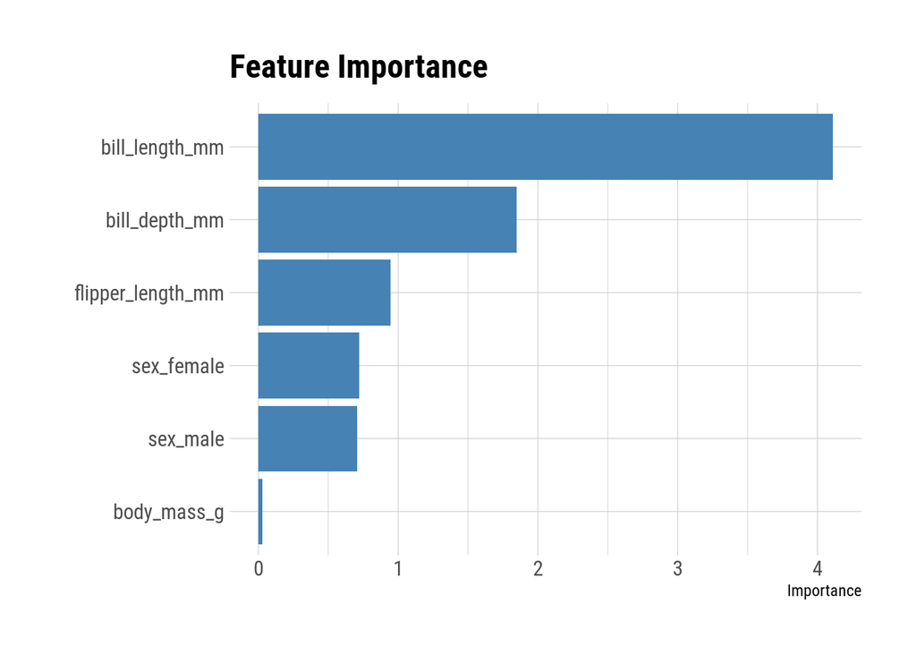

```r
library(vip)
final_model_op1 %>%
  fit(data = penguins_df) %>%
  pull_workflow_fit() %>%
  vip(
    geom = "col",
    aesthetics = list(fill = "steelblue")
  ) +
  labs(title = "Feature Importance")
```

## 7.2 Option 2: Workflow Sets Package

This way we can combine all possible models + recipes. A drawback is that you can’t assign custom tuning grids, it will use **grid_latin_hypercube** by default.

[Workflow Set Package](https://workflowsets.tidymodels.org/index.html)

[Latin hypercube grid](https://dials.tidymodels.org/reference/grid_max_entropy.html)

### 7.2.1 Install Workflow Sets Package

```r
# install.packages("devtools")
# library("devtools")
# devtools::install_github("tidymodels/workflowsets")
library(workflowsets)
```

### 7.2.2 Set Creation

```r
wfs_models <-
  workflow_set(
    models = list(
      ranger = ranger_model,
      glm = glm_model,
      xgb = xgboost_model
    ),
    preproc = list(
      rec_yj = recipe_1,
      rec_norm = recipe_2
    ),
    cross = TRUE
  )

wfs_models
```

| wflow_id | info | option | result |
| --- | --- | --- | --- |
| rec_yj_ranger |  |  |  |
| rec_yj_glm |  |  |  |
| rec_yj_xgb |  |  |  |
| rec_norm_ranger |  |  |  |
| rec_norm_glm |  |  |  |
| rec_norm_xgb |  |  |  |

Assuming **Ranger Model** doesn’t work with **recipe_2** specifications, we can remove it:

```r
wfs_models <-
  wfs_models %>%
  anti_join(tibble(wflow_id = c("rec_norm_ranger")), by = "wflow_id")

wfs_models
```

| wflow_id | info | option | result |
| --- | --- | --- | --- |
| rec_yj_ranger |  |  |  |
| rec_yj_glm |  |  |  |
| rec_yj_xgb |  |  |  |
| rec_norm_glm |  |  |  |
| rec_norm_xgb |  |  |  |

### 7.2.3 Training WF Sets

```r
tic("WF Sets Training time ")
wfs_models <-
  workflow_map(
    object = wfs_models,
    fn = "tune_grid", # OPTIONAL finetune::tune_race_anova
    resamples = data_penguins_5_cv_folds,
    grid = 10, # 10 HP combination
    metrics = model_metrics,
    verbose = TRUE
  )
```

```
## i 1 of 5 tuning:     rec_yj_ranger
```

```
## i Creating pre-processing data to finalize unknown parameter: mtry
```

```
## ✓ 1 of 5 tuning:     rec_yj_ranger (7.5s)
```

```
## i 2 of 5 tuning:     rec_yj_glm
```

```
## ✓ 2 of 5 tuning:     rec_yj_glm (7.9s)
```

```
## i 3 of 5 tuning:     rec_yj_xgb
```

```
## i Creating pre-processing data to finalize unknown parameter: mtry
```

```
## ✓ 3 of 5 tuning:     rec_yj_xgb (7.8s)
```

```
## i 4 of 5 tuning:     rec_norm_glm
```

```
## ✓ 4 of 5 tuning:     rec_norm_glm (9.4s)
```

```
## i 5 of 5 tuning:     rec_norm_xgb
```

```
## i Creating pre-processing data to finalize unknown parameter: mtry
```

```
## ✓ 5 of 5 tuning:     rec_norm_xgb (8.9s)
```

```r
toc()
```

```
## WF Sets Training time : 42.809 sec elapsed
```

### 7.2.4 Results

We have 5 models with 10 HP => 50 models to run

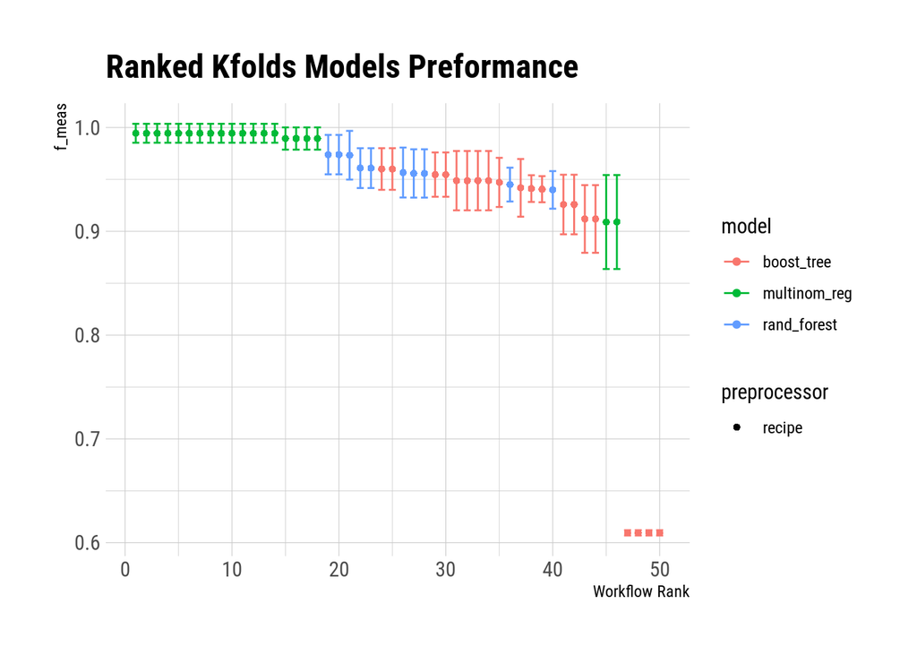

```r
autoplot(wfs_models, metric = "f_meas") + labs(title = "Ranked Kfolds Models Preformance")
```

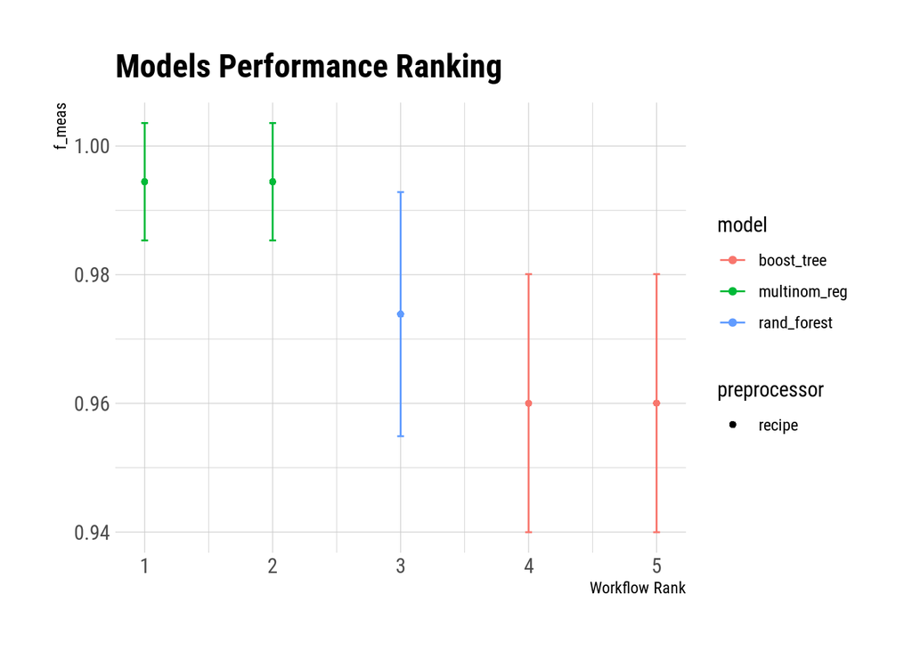

```r
autoplot(wfs_models, metric = "f_meas", select_best = TRUE) + labs(title = "Models Performance Ranking")
```

```r
rank_results(wfs_models, rank_metric = "f_meas", select_best = TRUE)
```

| wflow_id | .config | .metric | mean | std_err | n | preprocessor | model | rank |
| --- | --- | --- | --- | --- | --- | --- | --- | --- |
| rec_yj_glm | Preprocessor1_Model01 | f_meas | 0.9944524 | 0.0055475849 | 5 | recipe | multinom_reg | 1 |
| rec_yj_glm | Preprocessor1_Model01 | pr_auc | 0.4000000 | 0.2449489743 | 5 | recipe | multinom_reg | 1 |
| rec_norm_glm | Preprocessor1_Model01 | f_meas | 0.9944524 | 0.0055475849 | 5 | recipe | multinom_reg | 2 |
| rec_norm_glm | Preprocessor1_Model01 | pr_auc | 0.9990554 | 0.0009445914 | 5 | recipe | multinom_reg | 2 |
| rec_yj_ranger | Preprocessor1_Model01 | f_meas | 0.9738704 | 0.0115346570 | 5 | recipe | rand_forest | 3 |
| rec_yj_ranger | Preprocessor1_Model01 | pr_auc | 0.9909325 | 0.0060508659 | 5 | recipe | rand_forest | 3 |
| rec_norm_xgb | Preprocessor1_Model10 | f_meas | 0.9600320 | 0.0121952381 | 5 | recipe | boost_tree | 4 |
| rec_norm_xgb | Preprocessor1_Model10 | pr_auc | 0.9852156 | 0.0069345257 | 5 | recipe | boost_tree | 4 |
| rec_yj_xgb | Preprocessor1_Model10 | f_meas | 0.9600320 | 0.0121952381 | 5 | recipe | boost_tree | 5 |
| rec_yj_xgb | Preprocessor1_Model10 | pr_auc | 0.9849485 | 0.0070816857 | 5 | recipe | boost_tree | 5 |

### 7.2.5 Finalize WFS Models

Select the best workflow (model + recipe)

```r
wfs_glm_best_wf <-
  wfs_models %>%
  pull_workflow("rec_yj_glm") # Since all workflows are in the WFS object !!!

wfs_glm_best_wf
```

```
## ══ Workflow ════════════════════════════════════════════════════════════════════
## Preprocessor: Recipe
## Model: multinom_reg()
##
## ── Preprocessor ────────────────────────────────────────────────────────────────
## 2 Recipe Steps
##
## ● step_dummy()
## ● step_YeoJohnson()
##
## ── Model ───────────────────────────────────────────────────────────────────────
## Multinomial Regression Model Specification (classification)
##
## Main Arguments:
##   penalty = tune()
##   mixture = tune()
##
## Computational engine: glmnet
```

Select best model, get best parameters and create the final model

```r
wfs_best_f1 <-
  wfs_models %>%
  pull_workflow_result("rec_yj_glm") %>%
  select_best(metric = "f_meas")

final_model_wfs <-
  finalize_workflow(
    x = wfs_glm_best_wf,
    parameters = wfs_best_f1
  )

final_model_wfs
```

```
## ══ Workflow ════════════════════════════════════════════════════════════════════
## Preprocessor: Recipe
## Model: multinom_reg()
##
## ── Preprocessor ────────────────────────────────────────────────────────────────
## 2 Recipe Steps
##
## ● step_dummy()
## ● step_YeoJohnson()
##
## ── Model ───────────────────────────────────────────────────────────────────────
## Multinomial Regression Model Specification (classification)
##
## Main Arguments:
##   penalty = 8.16776434251831e-09
##   mixture = 0.0733483021147549
##
## Computational engine: glmnet
```

### 7.2.6 Last Fit WFS Models

```r
tic("Train final model WFS")
penguins_last_fit_wfs <-
  last_fit(final_model_wfs,
    penguins_split,
    metrics = model_metrics
  )
```

```
## ! train/test split: internal: There are `0` event cases in `truth`, results will be meaningl...
```

```r
toc(log = TRUE)
```

```
## Train final model WFS: 0.55 sec elapsed
```

#### 7.2.6.1 Last Fit WFS metrics

```r
collect_metrics(penguins_last_fit_wfs) %>%
  arrange(.metric)
```

| .metric | .estimator | .estimate | .config |
| --- | --- | --- | --- |
| f_meas | macro | 0.9876216 | Preprocessor1_Model1 |
| pr_auc | macro | 0.0000000 | Preprocessor1_Model1 |

```r
penguins_last_fit_wfs %>%
  collect_predictions() %>%
  conf_mat(truth = species, estimate = .pred_class)
```

```
##            Truth
## Prediction  Adelie Chinstrap Gentoo
##   Adelie        43         1      0
##   Chinstrap      0        19      0
##   Gentoo         0         0     35
```

```r
penguins_last_fit_wfs %>%
  pull(.predictions) %>%
  as.data.frame() %>%
  filter(.pred_class != species)
```

| .pred_class | .row | .pred_Adelie | .pred_Chinstrap | .pred_Gentoo | species | .config |
| --- | --- | --- | --- | --- | --- | --- |
| Adelie | 286 | NaN | NaN | NaN | Chinstrap | Preprocessor1_Model1 |

# 8 Models Training duration

```r
tic.log() %>%
  unlist() %>%
  tibble()
```

| . |
| --- |
| Ranger tune grid training duration : 10.382 sec elapsed |
| GLM tune grid training duration : 14.206 sec elapsed |
| XGBoost tune grid training duration : 14.275 sec elapsed |
| Tune race training duration : 19.837 sec elapsed |
| Train final model Tune: 0.561 sec elapsed |
| Train final model WFS: 0.55 sec elapsed |